# Social Determinants of Cesearean Section: Analysis of Results from the National Survey of Family Growth

Sabrina Morawej

### Overview

Medically unnecessary Cesarean sections (C-sections) are associated with poor health outcomes for mother and baby. This project will explore several social predictors of C-sections.

For this project, I conferred with Dr. Shimrit Keddem, PI at the Center for Health Equity, Research, and Promotion; she has used the NSFG in previous publications, and familiarized me with the National Survey of Family Growth which is a freely accessible dataset from the CDC to analyze my outcome. Dr. Keddem also helped me identify the revelant social predictors to explore this topic. Dr. Allison Curry, PI at the Center for Injury Research and Prevention helped me gather the background data on this topic and identify critical gaps in the literature. Finally, Professor Jessica Rast, STATA instructor and PhD Epidemiology candidate at Drexel University, taught me how to import the data into STATA so that it could then be imported into R.

[link to my repo](https://github.com/sem-22/BMIN503_Final_Project)

### Introduction

In 2020, about 26% of births in the United States ended in Cesarean delivery.[1] As C-section rates continue to rise in the United States, the Department of Health and Human Services announced one of the Healthy People 2030’s goals to reduce C-section rates among low-risk first births.[2] Compared to vaginal births, C-sections pose greater risks of complications at birth,[3] the postpartum period,[4] and negative long-term health outcomes.[5] These complications translate into high health care costs for patients, hospitals, and health insurance providers and diminished levels of maternal and infant health.[6–9]

The issue of rising rates of medically unneccessary C-sections requires an interdisciplinary approach. The goal of public healh is to prevent negative healh outcomes. Healh care providers, government officials, insurance companies, and hospital systems all share this goal. Additionally, they share another goal which is to reduce unneccessary medical costs. An economic and policy analysis contribute to the understanding of this insidious trend.

### Methods

I will use the National Survey of Family Growth’s (NSFG) 2017-2019 Female Pregnancy file for this analysis. The Female Pregnancy file is a subset of the NSFG that contains all relevant variables related to pregnancy and birth. The NSFG is a cross-sectional, nationally representative study conducted by the Centers for Disease Control and Prevention. For the purposes of this analysis, the analytic sample only includes first-births. The independent variables are prenatal care, age, insurance status, race/ethnicity, and smoking status during pregnancy. The dependent variable is C-section. Logistic regression will be used to explore the relationship between these social predictors and C-section.

As of today, the NSFG does not have downloadable files available for use in RStudio; nevertheless, the data were imported into R by creating a .dta outfile in STATA and then read into R through the appropriate “Import Dataset” feature. Using the *write.csv* command, the data were saved to R.

I will perform logistic regression to compare odds of having a c-section vs. a vaginal birth; therefore, I excluded all other pregnancy outcomes. The social predictors I am including in this analysis are: maternal age, number of cigarettes smoked per day during pregnancy, race, Hispanic origin, prenatal care, and insurance status.

```r
write.csv(nsfg, file = "nsfg.csv", row.names = FALSE, quote = FALSE)
```

```r
# save datafile in a way that R will save it when it's time to knit
nsfg <- read.csv("nsfg.csv")
```

There is a typo in the upload of 2017-2019 data which says this is the 2015-2017 NSFG, but each observation has a “Calendar year when interview occurred” (intvwyear) variable and all observations occurred within the stated 2017-2019 study period. I also contacted the NCHS, and I was reaffirmed that it was a mistype on their end.

```r
# WGT2017_2019: Final weight for the 2017-2019 NSFG; Applicable for all Respondents
# secu: Randomized version of the sampling error computational unit; : Applicable for all pregnancies (respondent-level variable)
# sest: Randomized version of the stratum; Applicable for all pregnancies (respondent-level variable)

# Clean the data
clean_nsfg <- nsfg %>%
    filter(pregordr == 1) %>% # filtering for responses about R's first pregnancy (all pregnancies after the first are excluded).
    select(PREGEND1, agepreg, npostsmk, race, hispanic, pncarewk, paydeliv, WGT2017_2019, secu, sest) %>% # selecting all relevant social predictors including my dependent variable.
    rename(birth.outcome = PREGEND1, mom.age = agepreg, cigs.per.day = npostsmk, prenatal.care = pncarewk, delivery.payment.type = paydeliv) %>% # giving vars common sense names
    mutate(birth.outcome = factor(birth.outcome, levels = c(5, 6), labels = c("C-section", "vaginal birth"))) %>% # by setting birth.outcome of first pregnancy to live c-section or live vaginal birth, I am creating a nominal, dichotomous outcome variable (which is what I need for logistic regression)
    mutate(cigs.per.day = factor(cigs.per.day, levels = c(1, 2, 3, 4, 6), labels = c("about 1", "2-4", "5-14", "15-24", "35-44"))) %>% # removed the "25-34" category (5th level) because this response was empty
    mutate(hispanic = factor(hispanic, levels = c(1, 2), labels = c("Hispanic", "Non-hispanic"))) %>%
    mutate(race = factor(race, levels = c(1, 2, 3), labels = c("Black", "White", "Other"))) %>%
    mutate(prenatal.care = factor(prenatal.care, levels = c(1, 2, 3), labels = c("<13 weeks", ">14 weeks", "no prenatal care"))) %>%
    mutate(delivery.payment.type = factor(delivery.payment.type, levels = c(1, 2, 3, 4, 5), labels = c("own income only", "insurance only", "own income & insurance only", "medicaid/govt assistance", "all other combinations of payment")))
```

### Results

Table 1: Descriptive Statistics of Study Population

```r
library(tableone)

## Vector of variables to summarize
myVars <- c("birth.outcome", "prenatal.care", "delivery.payment.type", "mom.age", "cigs.per.day", "race", "hispanic")

## Vector of categorical variables that need transformation
catVars <- c("birth.outcome", "prenatal.care", "delivery.payment.type", "cigs.per.day", "race", "hispanic")

## Create a TableOne object
table1 <- CreateTableOne(vars = myVars, data = clean_nsfg, factorVars = catVars)
table1
```

```
##
##                                        Overall
##   n                                     3709
##   birth.outcome = vaginal birth (%)     1875 (72.4)
##   prenatal.care (%)
##      <13 weeks                           575 (83.5)
##      >14 weeks                            42 ( 6.1)
##      no prenatal care                     72 (10.4)
##   delivery.payment.type (%)
##      own income only                      11 ( 2.1)
##      insurance only                      114 (21.3)
##      own income & insurance only         131 (24.4)
##      medicaid/govt assistance            260 (48.5)
##      all other combinations of payment    20 ( 3.7)
##   mom.age (mean (SD))                  22.28 (5.47)
##   cigs.per.day (%)
##      about 1                               8 (17.8)
##      2-4                                  20 (44.4)
##      5-14                                 11 (24.4)
##      15-24                                 6 (13.3)
##   race (%)
##      Black                               935 (25.2)
##      White                              2519 (67.9)
##      Other                               255 ( 6.9)
##   hispanic = Non-hispanic (%)           2646 (71.3)
```

Plots for bivariate relationships between each social predictor and birth outcome.

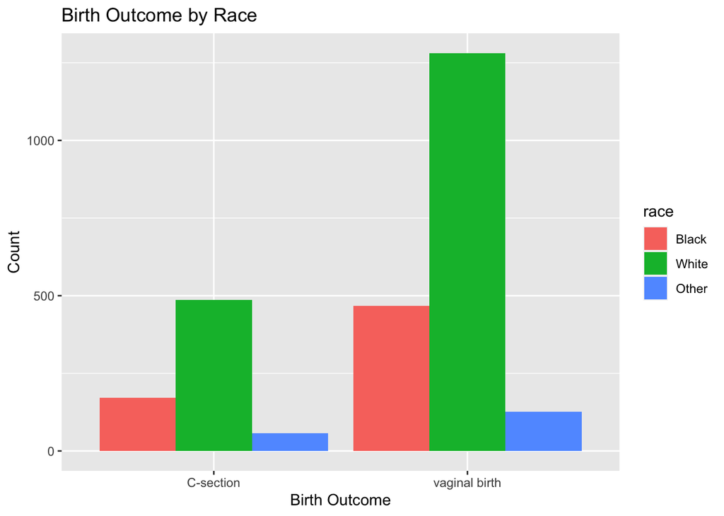

```r
# bar chart of women whose first birth was a C-section or vaginal birth by race (Black, white, and other)
clean_nsfg %>%
    drop_na(birth.outcome, race) %>%
    ggplot(aes(x = birth.outcome, fill = race)) +
    geom_bar(position = "dodge") +
    ggtitle("Birth Outcome by Race") +
    xlab("Birth Outcome") +
    ylab("Count")
```

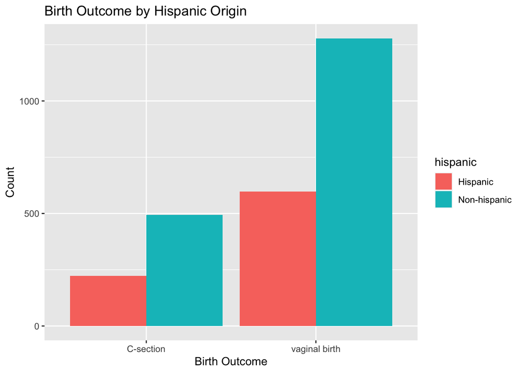

```r
# number of women whose first birth was a C-section or vaginal birth by Hispanic origin (Hispanic vs. non-Hispanic)
clean_nsfg %>%
    drop_na(birth.outcome, hispanic) %>%
    ggplot(aes(x = birth.outcome, fill = hispanic)) +
    geom_bar(position = "dodge") +
    ggtitle("Birth Outcome by Hispanic Origin") +
    xlab("Birth Outcome") +
    ylab("Count")
```

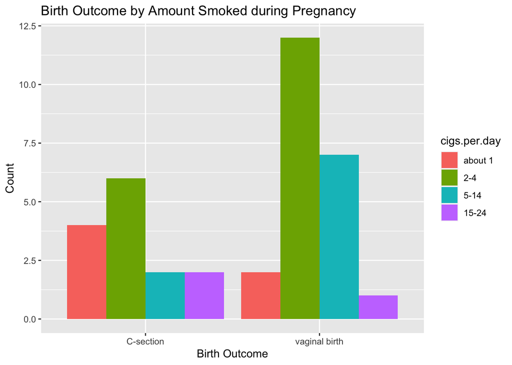

```r
# number of women whose first birth was a C-section or vaginal birth by the number of cigarettes she smoked during pregnancy after she knew she was pregnant
clean_nsfg %>%
    drop_na(birth.outcome, cigs.per.day) %>%
    ggplot(aes(x = birth.outcome, fill = cigs.per.day)) +
    geom_bar(position = "dodge") +
    ggtitle("Birth Outcome by Amount Smoked during Pregnancy") +
    xlab("Birth Outcome") +
    ylab("Count")
```

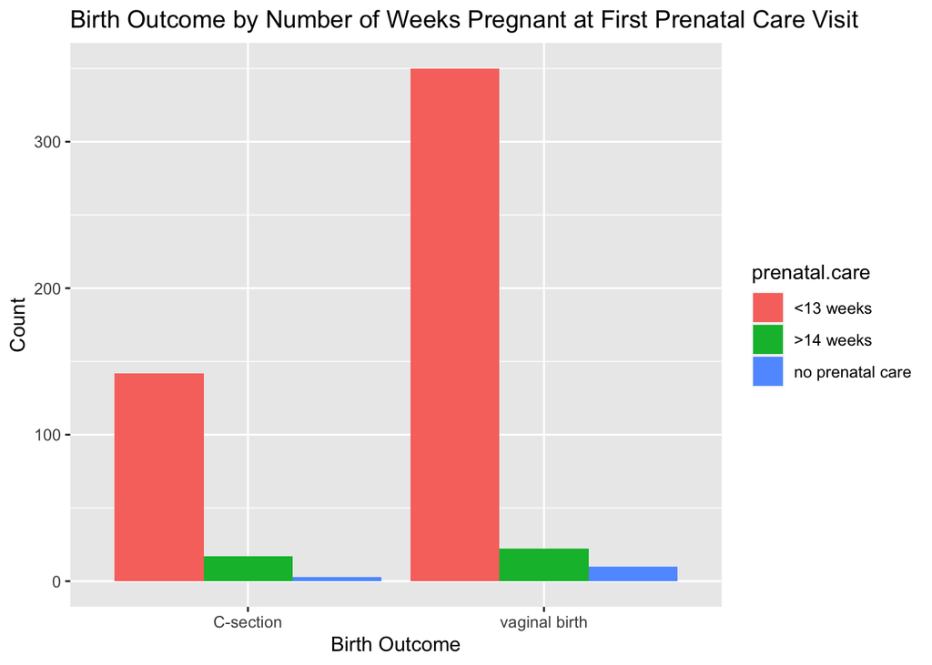

```r
# number of women whose first birth was a C-section or vaginal birth by the number of weeks pregnant at first prenatal care visit
clean_nsfg %>%
    drop_na(birth.outcome, prenatal.care) %>%
    ggplot(aes(x = birth.outcome, fill = prenatal.care)) +
    geom_bar(position = "dodge") +
    ggtitle("Birth Outcome by Number of Weeks Pregnant at First Prenatal Care Visit") +
    xlab("Birth Outcome") +
    ylab("Count")
```

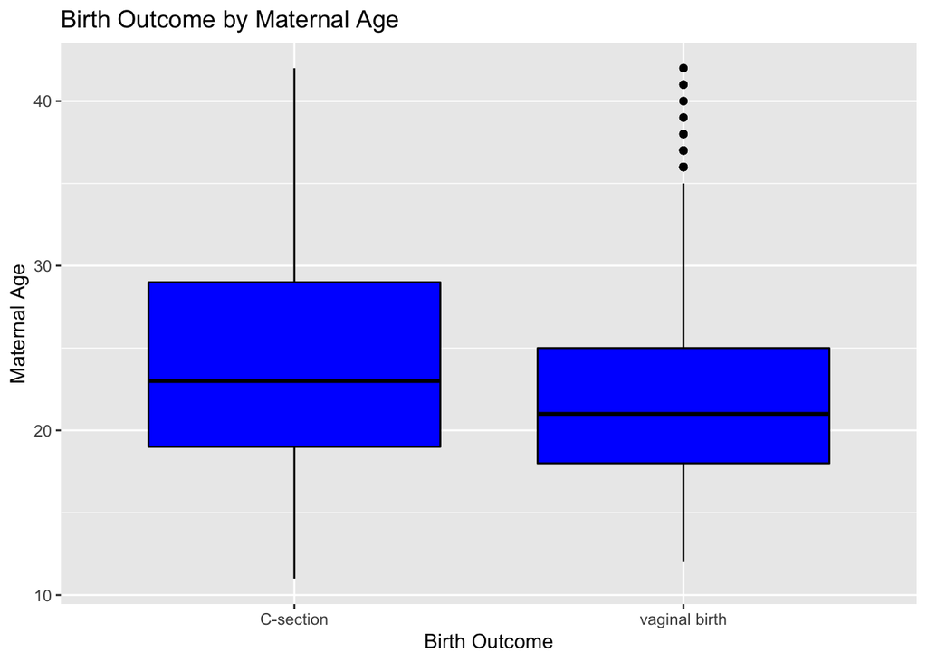

```r
# Maternal Age by C-section and vaginal birth
clean_nsfg %>%
     drop_na(birth.outcome, mom.age) %>%
    ggplot(aes(x = birth.outcome, y = mom.age)) +
    geom_boxplot(color = "black", fill = "blue") +
    ggtitle("Birth Outcome by Maternal Age") +
    xlab("Birth Outcome") +
    ylab("Maternal Age")
```

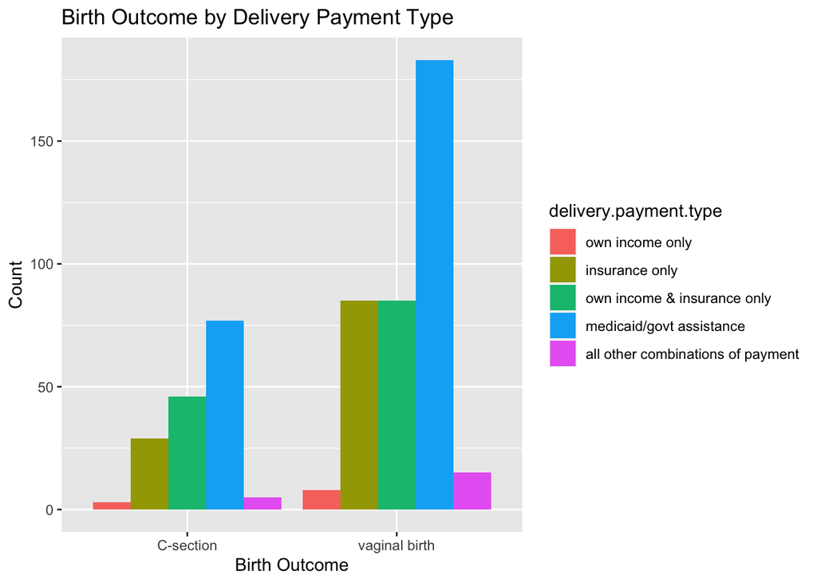

```r
# number of women whose first birth was a C-section or vaginal birth by the type of payment method for the delivery
clean_nsfg %>%
    drop_na(birth.outcome, delivery.payment.type) %>%
    ggplot(aes(x = birth.outcome, fill = delivery.payment.type)) +
    geom_bar(position = "dodge") +
    ggtitle("Birth Outcome by Delivery Payment Type") +
    xlab("Birth Outcome") +
    ylab("Count")
```

The crude odds ratios for each social predictor: maternal age, number of cigarettes smoked per day during pregnancy, race, Hispanic origin, prenatal care, and insurance status

```r
# maternal age (I/R variable)
summary(glm(birth.outcome ~ mom.age, data = clean_nsfg,
                  family = binomial()))
```

```
##
## Call:
## glm(formula = birth.outcome ~ mom.age, family = binomial(), data = clean_nsfg)
##
## Deviance Residuals:
##     Min       1Q   Median       3Q      Max
## -1.9675  -1.3360   0.7127   0.8013   1.3107
##
## Coefficients:
##              Estimate Std. Error z value Pr(>|z|)
## (Intercept)  2.520517   0.191562  13.158   <2e-16 ***
## mom.age     -0.067348   0.007925  -8.498   <2e-16 ***
## ---
## Signif. codes:  0 '***' 0.001 '**' 0.01 '*' 0.05 '.' 0.1 ' ' 1
##
## (Dispersion parameter for binomial family taken to be 1)
##
##     Null deviance: 3054.6  on 2590  degrees of freedom
## Residual deviance: 2981.9  on 2589  degrees of freedom
##   (1118 observations deleted due to missingness)
## AIC: 2985.9
##
## Number of Fisher Scoring iterations: 4
```

```r
# cigarettes smoked per day after confirming pregnancy (ordinal variable)
summary(glm(birth.outcome ~ cigs.per.day, data = clean_nsfg,
                  family = binomial()))
```

```
##
## Call:
## glm(formula = birth.outcome ~ cigs.per.day, family = binomial(),
##     data = clean_nsfg)
##
## Deviance Residuals:
##     Min       1Q   Median       3Q      Max
## -1.7344  -0.9005   0.7090   0.9005   1.4823
##
## Coefficients:
##                     Estimate Std. Error z value Pr(>|z|)
## (Intercept)       -6.931e-01  8.660e-01  -0.800   0.4235
## cigs.per.day2-4    1.386e+00  1.000e+00   1.386   0.1657
## cigs.per.day5-14   1.946e+00  1.180e+00   1.649   0.0992 .
## cigs.per.day15-24 -2.998e-15  1.500e+00   0.000   1.0000
## ---
## Signif. codes:  0 '***' 0.001 '**' 0.01 '*' 0.05 '.' 0.1 ' ' 1
##
## (Dispersion parameter for binomial family taken to be 1)
##
##     Null deviance: 48.114  on 35  degrees of freedom
## Residual deviance: 43.906  on 32  degrees of freedom
##   (3673 observations deleted due to missingness)
## AIC: 51.906
##
## Number of Fisher Scoring iterations: 4
```

```r
# race (nominal variable)
summary(glm(birth.outcome ~ race, data = clean_nsfg,
                  family = binomial()))
```

```
##
## Call:
## glm(formula = birth.outcome ~ race, family = binomial(), data = clean_nsfg)
##
## Deviance Residuals:
##     Min       1Q   Median       3Q      Max
## -1.6201  -1.6058   0.8028   0.8028   0.8611
##
## Coefficients:
##             Estimate Std. Error z value Pr(>|z|)
## (Intercept)  0.99883    0.08919  11.199   <2e-16 ***
## raceWhite   -0.03170    0.10387  -0.305    0.760
## raceOther   -0.19770    0.18268  -1.082    0.279
## ---
## Signif. codes:  0 '***' 0.001 '**' 0.01 '*' 0.05 '.' 0.1 ' ' 1
##
## (Dispersion parameter for binomial family taken to be 1)
##
##     Null deviance: 3054.6  on 2590  degrees of freedom
## Residual deviance: 3053.4  on 2588  degrees of freedom
##   (1118 observations deleted due to missingness)
## AIC: 3059.4
##
## Number of Fisher Scoring iterations: 4
```

```r
# Hispanic origin (nominal, dichotomous variable)
summary(glm(birth.outcome ~ hispanic, data = clean_nsfg,
                  family = binomial()))
```

```
##
## Call:
## glm(formula = birth.outcome ~ hispanic, family = binomial(),
##     data = clean_nsfg)
##
## Deviance Residuals:
##     Min       1Q   Median       3Q      Max
## -1.6138  -1.5992   0.7967   0.8078   0.8078
##
## Coefficients:
##                      Estimate Std. Error z value Pr(>|z|)
## (Intercept)           0.98475    0.07848   12.55   <2e-16 ***
## hispanicNon-hispanic -0.03220    0.09471   -0.34    0.734
## ---
## Signif. codes:  0 '***' 0.001 '**' 0.01 '*' 0.05 '.' 0.1 ' ' 1
##
## (Dispersion parameter for binomial family taken to be 1)
##
##     Null deviance: 3054.6  on 2590  degrees of freedom
## Residual deviance: 3054.5  on 2589  degrees of freedom
##   (1118 observations deleted due to missingness)
## AIC: 3058.5
##
## Number of Fisher Scoring iterations: 4
```

```r
# prenatal care (nominal variable)
summary(glm(birth.outcome ~ prenatal.care, data = clean_nsfg,
                  family = binomial()))
```

```
##
## Call:
## glm(formula = birth.outcome ~ prenatal.care, family = binomial(),
##     data = clean_nsfg)
##
## Deviance Residuals:
##     Min       1Q   Median       3Q      Max
## -1.7125  -1.5765   0.8253   0.8253   1.0701
##
## Coefficients:
##                               Estimate Std. Error z value Pr(>|z|)
## (Intercept)                     0.9021     0.0995   9.067   <2e-16 ***
## prenatal.care>14 weeks         -0.6443     0.3379  -1.907   0.0566 .
## prenatal.careno prenatal care   0.3019     0.6658   0.453   0.6502
## ---
## Signif. codes:  0 '***' 0.001 '**' 0.01 '*' 0.05 '.' 0.1 ' ' 1
##
## (Dispersion parameter for binomial family taken to be 1)
##
##     Null deviance: 662.57  on 543  degrees of freedom
## Residual deviance: 658.76  on 541  degrees of freedom
##   (3165 observations deleted due to missingness)
## AIC: 664.76
##
## Number of Fisher Scoring iterations: 4
```

```r
# payment type for delivery  (nominal variable)
summary(glm(birth.outcome ~ delivery.payment.type, data = clean_nsfg,
                  family = binomial()))
```

```
##
## Call:
## glm(formula = birth.outcome ~ delivery.payment.type, family = binomial(),
##     data = clean_nsfg)
##
## Deviance Residuals:
##     Min       1Q   Median       3Q      Max
## -1.6651  -1.4468   0.8181   0.8381   0.9301
##
## Coefficients:
##                                                        Estimate Std. Error z value Pr(>|z|)
## (Intercept)                                             0.98083    0.67700   1.449    0.147
## delivery.payment.typeinsurance only                     0.09453    0.71034   0.133    0.894
## delivery.payment.typeown income & insurance only       -0.36682    0.70131  -0.523    0.601
## delivery.payment.typemedicaid/govt assistance          -0.11515    0.69050  -0.167    0.868
## delivery.payment.typeall other combinations of payment  0.11778    0.85147   0.138    0.890
##
## (Dispersion parameter for binomial family taken to be 1)
##
##     Null deviance: 653.49  on 535  degrees of freedom
## Residual deviance: 650.44  on 531  degrees of freedom
##   (3173 observations deleted due to missingness)
## AIC: 660.44
##
## Number of Fisher Scoring iterations: 4
```

Table 2. Unadjusted ORs from the univariate regressions of each predictor

```
## add_global_p: Global p-values for variable(s) `add_global_p(include
## = c("mom.age", "cigs.per.day", "race", "hispanic", "prenatal.care",
## "delivery.payment.type"))` were calculated with
##   `car::Anova(mod = x$model_obj, type = "III")`
```

```
## add_q: Adjusting p-values with
## `stats::p.adjust(x$table_body$p.value, method = "fdr")`
```

| **Characteristic** | **N** | **Event N** | **OR**<sup>1</sup> | **95% CI**<sup>1</sup> | **p-value** | **q-value**<sup>2</sup> |
| --- | --- | --- | --- | --- | --- | --- |
| mom.age | 2591 | 1875 | 0.93 | 0.92, 0.95 | <0.001 | <0.001 |
| cigs.per.day | 36 | 22 |  |  | 0.24 | 0.48 |
| about 1 |  |  | — | — |  |  |
| 2-4 |  |  | 4.00 | 0.60, 35.5 |  |  |
| 5-14 |  |  | 7.00 | 0.79, 92.6 |  |  |
| 15-24 |  |  | 1.00 | 0.03, 19.3 |  |  |
| race | 2591 | 1875 |  |  | 0.56 | 0.67 |
| Black |  |  | — | — |  |  |
| White |  |  | 0.97 | 0.79, 1.19 |  |  |
| Other |  |  | 0.82 | 0.58, 1.18 |  |  |
| hispanic | 2591 | 1875 |  |  | 0.73 | 0.73 |
| Hispanic |  |  | — | — |  |  |
| Non-hispanic |  |  | 0.97 | 0.80, 1.16 |  |  |
| prenatal.care | 544 | 382 |  |  | 0.15 | 0.45 |
| <13 weeks |  |  | — | — |  |  |
| >14 weeks |  |  | 0.53 | 0.27, 1.03 |  |  |
| no prenatal care |  |  | 1.35 | 0.41, 6.10 |  |  |
| delivery.payment.type | 536 | 376 |  |  | 0.55 | 0.67 |
| own income only |  |  | — | — |  |  |
| insurance only |  |  | 1.10 | 0.23, 4.09 |  |  |
| own income & insurance only |  |  | 0.69 | 0.15, 2.53 |  |  |
| medicaid/govt assistance |  |  | 0.89 | 0.19, 3.17 |  |  |
| all other combinations of payment |  |  | 1.12 | 0.19, 5.89 |  |  |

<sup>*1*</sup> OR = Odds Ratio, CI = Confidence Interval <sup>*2*</sup> False discovery rate correction for multiple testing

The multivariate logistic regression with all predictors

```r
mlr <- birth.outcome.glm <- glm(birth.outcome ~ mom.age + cigs.per.day + race + hispanic + prenatal.care + delivery.payment.type, data = clean_nsfg, family = binomial())
```

Table 3. Adjusted ORs from the multiple logistic regressions of each predictor

```r
mlr %>%
  tbl_regression(exponentiate = TRUE) %>%
  bold_labels() %>%
  bold_p(t = 0.05)
```

[output not shown]

<sup>*1*</sup> OR = Odds Ratio, CI = Confidence Interval